# The Pursuit: Unraveling Homicides

## BUDT 704 - Group 20 (Criminal Minds) :

Lahari Tammera, Krithika Somasekhar, Priya Mullaputi, Abhishek Shetty, Biruk Makonnen, Niharika Gupta, Matthew Lin, Siddharth Modi

## **PROJECT OVERVIEW**

### Introduction :

In order to better understand the context, trends, and underlying causes of homicide in a particular location or across numerous regions, our study intends to provide a thorough analysis of homicide report data. This analysis includes the investigation of a number of homicide-related issues, including victim characteristics, crime scenes, suspects' intentions, and the influence of societal, economic, and environmental factors.

Homicide is a serious social problem with ramifications across society. It affects not only the criminal justice system but also critically affects social and public health. The focus of our study is to look deeply into homicide report data, which normally contains details about each homicide case, including the date, time, location, victim's characteristics, suspect information, cause of death, and, in some circumstances, the crime's motivation.

### Questions of Interest :

We have developed detailed and business-minded questions, which we will be addressing with our research and visualizations, following a careful review of the earlier inquiries and concept brainstorming. These inquiries will provide a more thorough understanding of the issues that our projects aims to address.

**#1 :** What are the most commonly used weapons in homicides and why might this be the case? What are the regions or cities that have the most homicides? Why?

**#2 :** What are the sex differences between homicide perpetrators and victims and the race breakdowns of victims? How have they changed over time?

**#3 :** Are there times when the number of homicides significantly rises or falls, and if so, what may have caused these changes—such as modifications to policy, changes in the economy, or adjustments to law enforcement tactics? Would any economic suffering or recession period contribute a significant effective relation to the frequency of homicide? Does the frequency vary based on season?

**#4 :** Correlation between perpetrator age and gender vs. victim age. Which generation would be the most affected by homicides? Is there any generation gap between the victim and the perpetrator?

**#5 :** For the crimes that were solved, which agency types were the most effective? Which states’ agencies were the best at solving the crimes? Which were the worst?

**#6 :** What kind of weapons did certain age groups prefer to use? What kind of weapons did the different genders given use?

**#7 :** What makes some areas more likely to have homicides, and can we use predictive analysis to find out which neighborhoods or city blocks are most at risk?

## Milestone and Progress :

**Task 1 (Due- 10/22/2023- completed )** : Access the quality of the data, Deciding whether or not predictive analysis is feasible, and method of data storage, Managing missing data, and exploratory data analysis.

The first step in our analytical process is a thorough examination of our dataset using exploratory data analysis (EDA) to evaluate its dependability and quality. Together, we assess the viability of predictive analysis while taking into account the subtleties and features of the dataset. Simultaneously, choices are made about how to store data and how to rearrange information such that it is readable. It becomes a collaborative effort to address missing data and put in place efficient data cleaning procedures, which enhances the overall accuracy of our analysis. This cooperative method guarantees our investigation is not only technically sound but also understandable and perceptive, laying the groundwork for a significant examination of our dataset.

**Task 2 ( Due - 11/07/2023- completed )** : Indexing/ Selection/ Filtering, Merging and reshaping data, Visualizations - Stacked bar chart , Geospatial analysis, Time series analysis ,Demographic analysis. -

As our project advances, we start a systematic process of indexing, selecting, and filtering, meticulously selecting the dataset to extract relevant data. This painstaking step prepares the groundwork for efficient data transformation, as well as the combining and repurposing of data, in which our combined efforts simplify the information into a more logical and significant shape. Using this improved dataset as a foundation, we use visual tools like stacked bar charts to extract intricate patterns and correlations from the data. We continue exploring with geospatial analysis, delving into the geographical aspects of our data to provide spatially complex insights.We next move into time series analysis to reveal the temporal features of our dataset and identify patterns and trends across time. At last, the focus shifts to demographic analysis, which offers a thorough comprehension of the many attributes included in our dataset.

**Task 3 (Due -11/10/2023- completed )**: Finding observations ,Creating inferences, Markdowns ,Comments ,Code review, Scrum style meetings.

In order to locate important patterns and insights, we must first carefully search through our dataset for observations. Expanding upon these findings, we started drawing conclusions and drawing inferences that add significance to the story of our research. We use comments and markdowns to expedite communication and documentation, guaranteeing transparency and clarity in our cooperative process. Using a code review methodology, we collaborate to assess and improve our code for efficacy and efficiency .

**Current status:**

Most of the things we listed in our project proposal timetable, we were able to do. We have completed the above mentioned tasks for first 4 questions of interest.

**Moving forward, for our next steps:**

We will complete our next set of questions and try to answer them using some analysis and visualizations.We plan to use a variety of visualization techniques in the next phase of our project, such as making a Sunburst chart to display hierarchical data relationships, a Scatter plot to find possible correlations, and a Cluster chart to look for patterns in the dataset.

For predictive analysis, to guarantee a strong training and testing phase for our models, we will deliberately divide the dataset in half at the same time. After that, our project will focus on training machine learning models, which will use algorithms to find patterns and connections in the data. Ultimately, we will use the trained models to produce predictions, which will provide insightful information and further the main objectives of our research. This comprehensive strategy uses machine learning and visualization techniques to extract valuable information from our dataset.

## Importing Libraries :

```python
# Import all required libraries
import numpy as np
import pandas as pd
import seaborn as sns
import matplotlib.pyplot as plt
from numpy import nan as NA
```

## Loading Dataset :

```python
# We would like to load our csv file in to a dataframe for processing and analysis
path = ''
homicides_df = pd.read_csv(path + 'database_Homicide.csv', dtype = { 16: 'str' })
```

```python
# Review dataset
homicides_df.head(50)
```

|  | Record ID | Agency Code | Agency Name | Agency Type | City | State | Year | Month | Incident | Crime Type | ... | Victim Ethnicity | Perpetrator Sex | Perpetrator Age | Perpetrator Race | Perpetrator Ethnicity | Relationship | Weapon | Victim Count | Perpetrator Count | Record Source |
| --- | --- | --- | --- | --- | --- | --- | --- | --- | --- | --- | --- | --- | --- | --- | --- | --- | --- | --- | --- | --- | --- |
| 0 | 1 | AK00101 | Anchorage | Municipal Police | Anchorage | Alaska | 1980 | January | 1 | Murder or Manslaughter | ... | Unknown | Male | 15 | Native American/Alaska Native | Unknown | Acquaintance | Blunt Object | 0 | 0 | FBI |
| 1 | 2 | AK00101 | Anchorage | Municipal Police | Anchorage | Alaska | 1980 | March | 1 | Murder or Manslaughter | ... | Unknown | Male | 42 | White | Unknown | Acquaintance | Strangulation | 0 | 0 | FBI |
| 2 | 3 | AK00101 | Anchorage | Municipal Police | Anchorage | Alaska | 1980 | March | 2 | Murder or Manslaughter | ... | Unknown | Unknown | 0 | Unknown | Unknown | Unknown | Unknown | 0 | 0 | FBI |
| 3 | 4 | AK00101 | Anchorage | Municipal Police | Anchorage | Alaska | 1980 | April | 1 | Murder or Manslaughter | ... | Unknown | Male | 42 | White | Unknown | Acquaintance | Strangulation | 0 | 0 | FBI |
| 4 | 5 | AK00101 | Anchorage | Municipal Police | Anchorage | Alaska | 1980 | April | 2 | Murder or Manslaughter | ... | Unknown | Unknown | 0 | Unknown | Unknown | Unknown | Unknown | 0 | 1 | FBI |
| 5 | 6 | AK00101 | Anchorage | Municipal Police | Anchorage | Alaska | 1980 | May | 1 | Murder or Manslaughter | ... | Unknown | Male | 36 | White | Unknown | Acquaintance | Rifle | 0 | 0 | FBI |
| 6 | 7 | AK00101 | Anchorage | Municipal Police | Anchorage | Alaska | 1980 | May | 2 | Murder or Manslaughter | ... | Unknown | Male | 27 | Black | Unknown | Wife | Knife | 0 | 0 | FBI |
| 7 | 8 | AK00101 | Anchorage | Municipal Police | Anchorage | Alaska | 1980 | June | 1 | Murder or Manslaughter | ... | Unknown | Male | 35 | White | Unknown | Wife | Knife | 0 | 0 | FBI |
| 8 | 9 | AK00101 | Anchorage | Municipal Police | Anchorage | Alaska | 1980 | June | 2 | Murder or Manslaughter | ... | Unknown | Unknown | 0 | Unknown | Unknown | Unknown | Firearm | 0 | 0 | FBI |
| 9 | 10 | AK00101 | Anchorage | Municipal Police | Anchorage | Alaska | 1980 | June | 3 | Murder or Manslaughter | ... | Unknown | Male | 40 | Unknown | Unknown | Unknown | Firearm | 0 | 1 | FBI |
| 10 | 11 | AK00101 | Anchorage | Municipal Police | Anchorage | Alaska | 1980 | July | 1 | Murder or Manslaughter | ... | Unknown | Unknown | 0 | Unknown | Unknown | Unknown | Unknown | 0 | 1 | FBI |
| 11 | 12 | AK00101 | Anchorage | Municipal Police | Anchorage | Alaska | 1980 | July | 2 | Murder or Manslaughter | ... | Unknown | Male | 49 | White | Unknown | Stranger | Shotgun | 0 | 0 | FBI |
| 12 | 13 | AK00101 | Anchorage | Municipal Police | Anchorage | Alaska | 1980 | July | 3 | Murder or Manslaughter | ... | Unknown | Male | 39 | Black | Unknown | Girlfriend | Blunt Object | 0 | 0 | FBI |
| 13 | 14 | AK00101 | Anchorage | Municipal Police | Anchorage | Alaska | 1980 | August | 1 | Murder or Manslaughter | ... | Unknown | Male | 49 | White | Unknown | Unknown | Fall | 0 | 0 | FBI |
| 14 | 15 | AK00101 | Anchorage | Municipal Police | Anchorage | Alaska | 1980 | August | 2 | Murder or Manslaughter | ... | Unknown | Unknown | 0 | Unknown | Unknown | Unknown | Handgun | 0 | 0 | FBI |
| 15 | 16 | AK00101 | Anchorage | Municipal Police | Anchorage | Alaska | 1980 | August | 3 | Murder or Manslaughter | ... | Unknown | Female | 29 | Black | Unknown | Ex-Husband | Handgun | 0 | 0 | FBI |
| 16 | 17 | AK00101 | Anchorage | Municipal Police | Anchorage | Alaska | 1980 | December | 1 | Murder or Manslaughter | ... | Unknown | Male | 19 | Unknown | Unknown | Acquaintance | Knife | 0 | 0 | FBI |
| 17 | 18 | AK00103 | Juneau | Municipal Police | Juneau | Alaska | 1980 | November | 1 | Murder or Manslaughter | ... | Unknown | Male | 23 | Native American/Alaska Native | Unknown | Brother | Blunt Object | 0 | 1 | FBI |
| 18 | 19 | AK00106 | Nome | Municipal Police | Nome | Alaska | 1980 | June | 1 | Murder or Manslaughter | ... | Unknown | Male | 33 | Native American/Alaska Native | Unknown | Acquaintance | Handgun | 0 | 0 | FBI |
| 19 | 20 | AK00113 | Bethel | Municipal Police | Bethel | Alaska | 1980 | February | 1 | Murder or Manslaughter | ... | Unknown | Male | 35 | Native American/Alaska Native | Unknown | Brother | Handgun | 0 | 0 | FBI |
| 20 | 21 | AK00118 | North Slope Borough | County Police | North Slope | Alaska | 1980 | August | 1 | Murder or Manslaughter | ... | Unknown | Male | 29 | Unknown | Unknown | Stepdaughter | Rifle | 2 | 0 | FBI |
| 21 | 22 | AK00118 | North Slope Borough | County Police | North Slope | Alaska | 1980 | August | 1 | Murder or Manslaughter | ... | Unknown | Male | 29 | Unknown | Unknown | Stepdaughter | Rifle | 2 | 0 | FBI |
| 22 | 23 | AK00118 | North Slope Borough | County Police | North Slope | Alaska | 1980 | June | 1 | Murder or Manslaughter | ... | Unknown | Male | 26 | Unknown | Unknown | Acquaintance | Knife | 0 | 0 | FBI |
| 23 | 24 | AK00118 | North Slope Borough | County Police | North Slope | Alaska | 1980 | July | 1 | Manslaughter by Negligence | ... | Unknown | Male | 41 | Unknown | Unknown | Wife | Blunt Object | 0 | 0 | FBI |
| 24 | 25 | AK00118 | North Slope Borough | County Police | North Slope | Alaska | 1980 | August | 1 | Murder or Manslaughter | ... | Unknown | Male | 29 | Unknown | Unknown | Stepdaughter | Rifle | 2 | 0 | FBI |
| 25 | 26 | AK00123 | Kenai | Municipal Police | Kenai Peninsula | Alaska | 1980 | February | 1 | Murder or Manslaughter | ... | Unknown | Male | 42 | White | Unknown | Wife | Handgun | 0 | 0 | FBI |
| 26 | 27 | AKASP00 | Alaska State Police | State Police | Juneau | Alaska | 1980 | February | 1 | Murder or Manslaughter | ... | Unknown | Unknown | 0 | Unknown | Unknown | Unknown | Handgun | 0 | 0 | FBI |
| 27 | 28 | AKASP00 | Alaska State Police | State Police | Juneau | Alaska | 1980 | February | 2 | Murder or Manslaughter | ... | Unknown | Female | 28 | Native American/Alaska Native | Unknown | Husband | Handgun | 0 | 0 | FBI |
| 28 | 29 | AKASP00 | Alaska State Police | State Police | Juneau | Alaska | 1980 | February | 3 | Murder or Manslaughter | ... | Unknown | Female | 36 | Native American/Alaska Native | Unknown | Brother | Rifle | 0 | 0 | FBI |
| 29 | 30 | AKASP00 | Alaska State Police | State Police | Juneau | Alaska | 1980 | April | 1 | Murder or Manslaughter | ... | Unknown | Male | 61 | Native American/Alaska Native | Unknown | Unknown | Shotgun | 0 | 0 | FBI |
| 30 | 31 | AKASP00 | Alaska State Police | State Police | Juneau | Alaska | 1980 | May | 1 | Murder or Manslaughter | ... | Unknown | Male | 25 | White | Unknown | Brother | Rifle | 0 | 0 | FBI |
| 31 | 32 | AKASP00 | Alaska State Police | State Police | Juneau | Alaska | 1980 | June | 1 | Manslaughter by Negligence | ... | Unknown | Male | 7 | Asian/Pacific Islander | Unknown | Sister | Rifle | 0 | 0 | FBI |
| 32 | 33 | AKASP00 | Alaska State Police | State Police | Juneau | Alaska | 1980 | July | 1 | Murder or Manslaughter | ... | Unknown | Unknown | 0 | Unknown | Unknown | Unknown | Unknown | 0 | 0 | FBI |
| 33 | 34 | AKASP00 | Alaska State Police | State Police | Juneau | Alaska | 1980 | July | 2 | Murder or Manslaughter | ... | Unknown | Unknown | 0 | Unknown | Unknown | Unknown | Unknown | 0 | 0 | FBI |
| 34 | 35 | AKASP00 | Alaska State Police | State Police | Juneau | Alaska | 1980 | July | 3 | Murder or Manslaughter | ... | Unknown | Unknown | 0 | Unknown | Unknown | Unknown | Firearm | 0 | 0 | FBI |
| 35 | 36 | AKASP00 | Alaska State Police | State Police | Juneau | Alaska | 1980 | August | 1 | Murder or Manslaughter | ... | Unknown | Male | 17 | Native American/Alaska Native | Unknown | Unknown | Rifle | 0 | 0 | FBI |
| 36 | 37 | AKASP00 | Alaska State Police | State Police | Juneau | Alaska | 1980 | August | 2 | Murder or Manslaughter | ... | Unknown | Male | 34 | White | Unknown | Unknown | Rifle | 0 | 0 | FBI |
| 37 | 38 | AKASP00 | Alaska State Police | State Police | Juneau | Alaska | 1980 | October | 1 | Murder or Manslaughter | ... | Unknown | Male | 28 | Native American/Alaska Native | Unknown | Acquaintance | Rifle | 0 | 0 | FBI |
| 38 | 39 | AKASP00 | Alaska State Police | State Police | Juneau | Alaska | 1980 | October | 2 | Murder or Manslaughter | ... | Unknown | Unknown | 0 | Unknown | Unknown | Unknown | Firearm | 0 | 0 | FBI |
| 39 | 40 | AKASP00 | Alaska State Police | State Police | Juneau | Alaska | 1980 | October | 3 | Manslaughter by Negligence | ... | Unknown | Male | 49 | White | Unknown | Acquaintance | Rifle | 0 | 0 | FBI |
| 40 | 41 | AKASP00 | Alaska State Police | State Police | Juneau | Alaska | 1980 | October | 4 | Manslaughter by Negligence | ... | Unknown | Male | 21 | White | Unknown | Friend | Rifle | 0 | 0 | FBI |
| 41 | 42 | AKASP00 | Alaska State Police | State Police | Juneau | Alaska | 1980 | November | 1 | Murder or Manslaughter | ... | Unknown | Male | 43 | White | Unknown | Friend | Handgun | 0 | 0 | FBI |
| 42 | 43 | AKASP00 | Alaska State Police | State Police | Juneau | Alaska | 1980 | November | 2 | Murder or Manslaughter | ... | Unknown | Male | 42 | Native American/Alaska Native | Unknown | Family | Rifle | 0 | 0 | FBI |
| 43 | 44 | AKASP00 | Alaska State Police | State Police | Juneau | Alaska | 1980 | November | 3 | Manslaughter by Negligence | ... | Unknown | Male | 36 | White | Unknown | Friend | Rifle | 0 | 0 | FBI |
| 44 | 45 | AKASP00 | Alaska State Police | State Police | Juneau | Alaska | 1980 | November | 4 | Manslaughter by Negligence | ... | Not Hispanic | Male | 26 | Native American/Alaska Native | Not Hispanic | Wife | Drowning | 0 | 0 | FBI |
| 45 | 46 | AKASP00 | Alaska State Police | State Police | Juneau | Alaska | 1980 | December | 1 | Murder or Manslaughter | ... | Unknown | Male | 23 | Native American/Alaska Native | Unknown | Friend | Knife | 0 | 0 | FBI |
| 46 | 47 | AKASP00 | Alaska State Police | State Police | Juneau | Alaska | 1980 | December | 2 | Manslaughter by Negligence | ... | Unknown | Female | 27 | Native American/Alaska Native | Unknown | Husband | Rifle | 0 | 0 | FBI |
| 47 | 48 | AL00100 | Jefferson | Sheriff | Jefferson | Alabama | 1980 | February | 1 | Murder or Manslaughter | ... | Unknown | Male | 43 | Black | Unknown | Neighbor | Rifle | 0 | 0 | FBI |
| 48 | 49 | AL00100 | Jefferson | Sheriff | Jefferson | Alabama | 1980 | March | 1 | Murder or Manslaughter | ... | Unknown | Female | 38 | White | Unknown | Husband | Shotgun | 0 | 0 | FBI |
| 49 | 50 | AL00100 | Jefferson | Sheriff | Jefferson | Alabama | 1980 | April | 1 | Murder or Manslaughter | ... | Unknown | Male | 66 | Black | Unknown | Acquaintance | Handgun | 0 | 0 | FBI |

50 rows × 24 columns

```python
# Checking our data rows and coloumns
homicides_df.shape
print(f'No. of rows: {homicides_df.shape[0]}')
print(f'No. of colums: {homicides_df.shape[1]}')
```

```
No. of rows: 638454
No. of colums: 24
```

# Data Cleaning :

```python
# Dropping some columns that we will not use for later analysis
homicides_df.drop(columns=['Record Source', 'Perpetrator Race', 'Perpetrator Ethnicity'], inplace=True)
```

The code eliminates these columns in an attempt to streamline the dataset, increase computing performance, cut down on redundancy, and concentrate on the most important aspects for the latter phases of analysis. In order to enable a more effective and efficient analysis process, this operation proposes a planned and focused approach, highlighting the significance of feature selection and simplified data.

```python
# checking to see if we have any duplicates
print(f'No. of duplicate rows: {homicides_df.duplicated().sum()}')
```

```
No. of duplicate rows: 0
```

There are no duplicated records.

```python
# Using this to check for missing/blank values in the dataset column wise
missing_vals = homicides_df.isnull().sum()
missing_vals
```

```
Record ID            0
Agency Code          0
Agency Name          0
Agency Type          0
City                 0
State                0
Year                 0
Month                0
Incident             0
Crime Type           0
Crime Solved         0
Victim Sex           0
Victim Age           0
Victim Race          0
Victim Ethnicity     0
Perpetrator Sex      0
Perpetrator Age      0
Relationship         0
Weapon               0
Victim Count         0
Perpetrator Count    0
dtype: int64
```

We have found no missing values

While reviewing the dataframe we found that instead of NaN we have 'Unknown' as the missing value. So, let's replace it.

```python
# Find count of 'Unknown' in each column
unknown_counts = {}
for column in homicides_df.columns:
    unknown_counts[column] = (homicides_df[column] == 'Unknown').sum()

print(unknown_counts)
```

[output not shown]

```python
# Replace 'Unknown' with Nan
homicides_df.replace('Unknown', NA,inplace=True)
homicides_df.head(10)
```

| Record ID | Agency Code | Agency Name | Agency Type | City | State | Year | Month | Incident | Crime Type | Crime Solved | Victim Sex | Victim Age | Victim Race | Victim Ethnicity | Perpetrator Sex | Perpetrator Age | Relationship | Weapon | Victim Count | Perpetrator Count |
| --- | --- | --- | --- | --- | --- | --- | --- | --- | --- | --- | --- | --- | --- | --- | --- | --- | --- | --- | --- | --- |
| 1 | AK00101 | Anchorage | Municipal Police | Anchorage | Alaska | 1980 | January | 1 | Murder or Manslaughter | Yes | Male | 14 | Native American/Alaska Native | NaN | Male | 15 | Acquaintance | Blunt Object | 0 | 0 |
| 2 | AK00101 | Anchorage | Municipal Police | Anchorage | Alaska | 1980 | March | 1 | Murder or Manslaughter | Yes | Male | 43 | White | NaN | Male | 42 | Acquaintance | Strangulation | 0 | 0 |
| 3 | AK00101 | Anchorage | Municipal Police | Anchorage | Alaska | 1980 | March | 2 | Murder or Manslaughter | No | Female | 30 | Native American/Alaska Native | NaN | NaN | 0 | NaN | NaN | 0 | 0 |
| 4 | AK00101 | Anchorage | Municipal Police | Anchorage | Alaska | 1980 | April | 1 | Murder or Manslaughter | Yes | Male | 43 | White | NaN | Male | 42 | Acquaintance | Strangulation | 0 | 0 |
| 5 | AK00101 | Anchorage | Municipal Police | Anchorage | Alaska | 1980 | April | 2 | Murder or Manslaughter | No | Female | 30 | Native American/Alaska Native | NaN | NaN | 0 | NaN | NaN | 0 | 1 |
| 6 | AK00101 | Anchorage | Municipal Police | Anchorage | Alaska | 1980 | May | 1 | Murder or Manslaughter | Yes | Male | 30 | White | NaN | Male | 36 | Acquaintance | Rifle | 0 | 0 |
| 7 | AK00101 | Anchorage | Municipal Police | Anchorage | Alaska | 1980 | May | 2 | Murder or Manslaughter | Yes | Female | 42 | Native American/Alaska Native | NaN | Male | 27 | Wife | Knife | 0 | 0 |
| 8 | AK00101 | Anchorage | Municipal Police | Anchorage | Alaska | 1980 | June | 1 | Murder or Manslaughter | Yes | Female | 99 | White | NaN | Male | 35 | Wife | Knife | 0 | 0 |
| 9 | AK00101 | Anchorage | Municipal Police | Anchorage | Alaska | 1980 | June | 2 | Murder or Manslaughter | No | Male | 32 | White | NaN | NaN | 0 | NaN | Firearm | 0 | 0 |
| 10 | AK00101 | Anchorage | Municipal Police | Anchorage | Alaska | 1980 | June | 3 | Murder or Manslaughter | Yes | Male | 38 | White | NaN | Male | 40 | NaN | Firearm | 0 | 1 |

## Index Dataset :

```python
# Setting the index as the 'Record ID' column for easier viewing
homicides_df.set_index('Record ID', inplace = True)
homicides_df
```

[output not shown]

638454 rows × 20 columns

The code restructures the DataFrame so that the 'Record ID' values serve as the row identifiers by assigning the 'Record ID' column to the index. This change was made to improve data exploration's simplicity of use and clarity. By assigning a unique identification to the index, We are able to get individual entries, make data retrieval more efficient, and make the DataFrame easier to read overall.

## Exploratory Data Analysis :

To get a better overview of dataset, we will do exploratory data analysis.

```python
# we are trying to see which of our data are numerical or catagorical for better understanding of our data
def get_var_category(series):
    unique_count = series.nunique(dropna=False)
    total_count = len(series)
    if pd.api.types.is_numeric_dtype(series):
        return 'Numerical'
    elif pd.api.types.is_datetime64_dtype(series):
        return 'Date'
    elif unique_count==total_count:
        return 'Text (Unique)'
    else:
        return 'Categorical'

def print_categories(df):
    for column_name in df.columns:
        print(column_name, ": ", get_var_category(df[column_name]))
print_categories(homicides_df)
```

The code gives a thorough description of the characteristics of each column in the dataset by differentiating between date, category, and numerical variables. This classification is crucial since it provides the framework for customized analytical methods and well-informed decision-making. we are better equipped to use suitable statistical measurements, visualization approaches, and modeling tactics when we know whether a variable is numerical, categorical, or temporal. Additionally, the code highlights columns that have distinct text values, indicating possible areas that need extra investigation, including abnormalities or inconsistencies in the data.

```python
# we are trying to descibe age trend of victim from our data set
homicides_df['Victim Age'].describe()
```

```
count    638454.000000
mean         35.033512
std          41.628306
min           0.000000
25%          22.000000
50%          30.000000
75%          42.000000
max         998.000000
Name: Victim Age, dtype: float64
```

```python
# to change the type of perpetrator age
perpetrator_age = pd.to_numeric(homicides_df['Perpetrator Age'], errors='coerce')
perpetrator_age.describe()
```

```
count    638453.000000
mean         20.322697
std          17.886842
min           0.000000
25%           0.000000
50%          21.000000
75%          31.000000
max          99.000000
Name: Perpetrator Age, dtype: float64
```

# Data Analysis & Visualization :

Let's take a closer look at the data using some visualizations. We want to answer a variety of questions based on the data, so that we can improve our understanding of the homicide data and maybe even predict some trends. Mainly, we want to be able to view the data in a concise manner and then make some inferences based on our visualizations.

Let's get started!

### **Question of Interest #1 :**

What are the most common weapons used in homicides, and how do they alter depending on geography and demographics? What are the regions or cities that have the most homicides and which causes are the most prevalent in each state?

Let us first discuss part one of our question. What are the most common weapons used in homicides and why might this be the case?

```python
# showing the different weapons used
weapon_count = homicides_df['Weapon'].value_counts()
weapon_count
```

```
Handgun          317484
Knife             94962
Blunt Object      67337
Firearm           46980
Shotgun           30722
Rifle             23347
Strangulation      8110
Fire               6173
Suffocation        3968
Gun                2206
Drugs              1588
Drowning           1204
Explosives          537
Poison              454
Fall                190
Name: Weapon, dtype: int64
```

### Let's make an observation based on the initial breakdown :

Handguns are the most common weapon in these kinds of situations, suggesting that they are widely available and versatile. The use of knives and blunt items later on emphasizes how important close-quarters physical aggression is. The various ways that guns are used, including shotguns, rifles, and general purpose guns, add up to a significant number. There are also less prevalent techniques like drowning, fire, suffocation, and strangulation, all of which shed light on the various circumstances surrounding some crimes.

### Now, let's create a visualization of this!

We want to be able to view the most common weapons used in homicides over the years and make an inference based on the visualization.

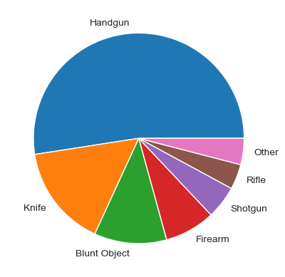

```python
threshold = 10000
small_counts = weapon_count[weapon_count < threshold]
weapon_count['Other'] = weapon_count[small_counts.index].sum()
weapon_count.drop(small_counts.index, inplace=True)
plt.pie(weapon_count, labels = weapon_count.index)
plt.show()
```

### Let's make an inference based on our visualization :

Let us discuss part two of our question. What are the regions or cities that have the most homicides? Why?

### Now, let's create a visualization of this!

We want to be able to view the cities with the highest homicide rates and then create an observation and an inference based on what we see.

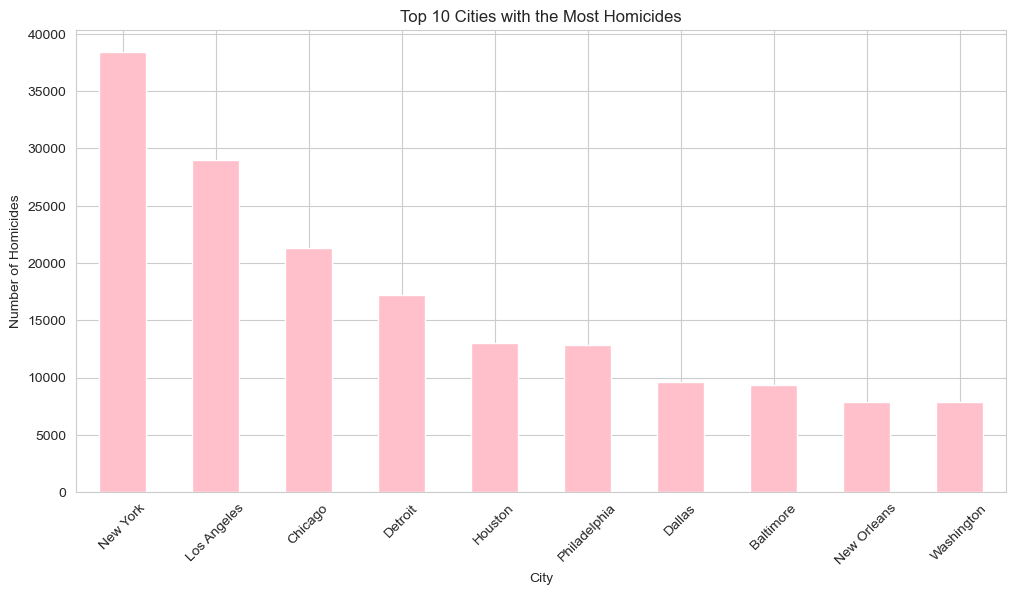

```python
# Grouping data by cities and counting the number of homicides in each city
city_homicide_counts = homicides_df.groupby('Agency Name')['City'].count().sort_values(ascending=False)

# Grouping data by states and finding the most prevalent causes in each state
state_weapon_counts = homicides_df.groupby('State')['Weapon'].value_counts().groupby(level=0).nlargest(1)

# Plotting the cities with the most homicides
plt.figure(figsize=(12, 6))
city_homicide_counts.head(10).plot(kind='bar', color='pink')
plt.title('Top 10 Cities with the Most Homicides')
plt.xlabel('City')
plt.ylabel('Number of Homicides')
plt.xticks(rotation=45)
plt.show()
```

### Let's make an observation based on our visualization :

The given code provides a thorough analysis of the homicide data, first classifying it by city to ascertain the total number of homicides in each. Los Angeles, Chicago, and New York are the three cities with the highest incidence of homicides, while the top 10 cities with the highest counts are prominently displayed in the resulting bar chart. This graphic depiction gives a clear picture of the cities with high homicide rates by highlighting the spatial distribution of violent episodes.Furthermore, the code looks at data at the state level to determine the weapon most frequently used in homicides in each state, providing a more comprehensive view of the various techniques utilized in deadly situations in various locations.

### Let's make an inference based on our visualization :

A number of intricate socioeconomic and demographic factors may contribute to increased homicide rates in Los Angeles, Chicago, and New York City. Big cities frequently struggle with problems like gang activity, poverty, and a concentration of underprivileged neighborhoods. Homicides and other crimes may occur at higher rates as a result of these circumstances. Social unrest and criminal activity may be exacerbated by economic inequality and restricted access to jobs and educational possibilities in some communities. Increased population density, difficulties with law enforcement, and easier access to firearms could all contribute to an increased risk of violent occurrences. The convergence of these factors in major metropolitan areas such as Los Angeles, Chicago, and New York highlights the need for targeted and multifaceted approaches to address the underlying causes of violence

### **Question of Interest #2 :**

What are the sex differences between homicide perpetrators and victims and the race breakdowns of victims? How have they changed over time?

Let us first do some basic analysis on perpetrator sex versus victim sex.

```python
# creating homicides count based on victom sex to see the distributions
victim_sex_count = homicides_df['Victim Sex'].value_counts()
victim_sex_count
```

```
Male      494125
Female    143345
Name: Victim Sex, dtype: int64
```

With 494,125 occurrences, the data shows that men make up a significant majority of the victims. This greatly exceeds the 143,345 recorded number of female victims. The notable gap between the number of victims by gender begs the question of what factors are at play and necessitates more research into the demographics of homicide episodes. It is imperative to comprehend gender dynamics in order to formulate focused interventions and policies that target and prevent violence. This underscores the significance of accurate and thorough data collecting in crime reporting.

```python
# creating homicides count based on perpetrator sex to compare between the two
perpetrator_sex_count = homicides_df['Perpetrator Sex'].value_counts()
perpetrator_sex_count
```

```
Male      399541
Female     48548
Name: Perpetrator Sex, dtype: int64
```

### Now, let's create a visualization of this!

We want to be able to view the breakdown between perpetrator sex and victim sex and create an inference based on the visualization.

[figure not shown]

```python
x = homicides_df['Victim Sex'].value_counts().index
y1 = homicides_df['Victim Sex'].value_counts()
y2 = homicides_df['Perpetrator Sex'].value_counts()

data = pd.DataFrame({'Gender': x, 'Victim': y1, 'Perpetrator': y2})

victim_color = 'pink'
perpetrator_color = 'lavender'

sns.set_style("whitegrid")
plt.figure(figsize=(10, 6))

for i, gender in enumerate(x_filtered):
    total_count = y1_filtered[i] + y2_filtered[i]
    victim_percentage = y1_filtered[i] / total_count * 100
    perpetrator_percentage = y2_filtered[i] / total_count * 100

    plt.bar(x_filtered[i], y1_filtered[i], color=victim_color, label="Victim" if i == 0 else "")
    plt.bar(x_filtered[i], y2_filtered[i], bottom=y1_filtered[i], color=perpetrator_color, label="Perpetrator" if i == 0 else "")

    plt.text(i, y1_filtered[i] / 2, f'{victim_percentage:.1f}%', ha='center', va='center', color='black', fontsize=14)
    plt.text(i, y1_filtered[i] + y2_filtered[i] / 2, f'{perpetrator_percentage:.1f}%', ha='center', va='center', color='black', fontsize=14)

plt.xlabel('Gender', fontsize=14)
plt.ylabel('Percentage', fontsize=14)
plt.title('Gender Percentage Histogram', fontsize=16)
plt.xticks(fontsize=12)
plt.yticks(fontsize=12)
sns.despine(top=True, right=True)

plt.legend(title="Role", labels=["Victim", "Perpetrator"], fontsize=12)

plt.tight_layout()
plt.show()
```

### Let's make an inference based on our visualization :

The gender distribution of homicide victims and perpetrators is shown in the stacked bar chart. Males predominate in both occupations, with far greater counts than females; this could be a reflection of underlying criminological and social trends. Crime statistics in the past have consistently demonstrated that men are more likely than women to be involved in violent crimes, both as offenders and victims. This could be due to a number of things, including socialization, cultural norms, and the frequency of particular risk factors that are more common in men.Furthermore, the noteworthy number of gender cases that are marked as "Unknown" highlights difficulties in gathering and reporting data, either pointing to holes in the investigation process or restrictions in the resources available.

Next, let's do some basic analysis on victim race and make an observation.

```python
# creating a count based on race to see who is affected the most
victim_race_count = homicides_df['Victim Race'].value_counts()
victim_race_count
```

```
White                            317422
Black                            299899
Asian/Pacific Islander             9890
Native American/Alaska Native      4567
Name: Victim Race, dtype: int64
```

### Now, let's create a visualization of this!

We want to be able to view the breakdown of victim race, so that we can make an inference of why certain populations are more affected.

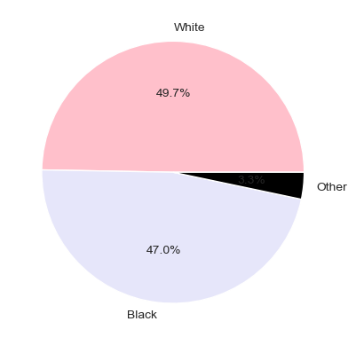

```python
# we would like to show the distribution of victim race
y = np.array([316521, 299126, 9851+6625+4557])
mylabels = ['White', 'Black','Other']
mycolors = ['pink', 'lavender', 'black']
fig, ax = plt.subplots()
ax.pie(y, labels=mylabels, autopct='%.1f%%')
myexplode = [0, 0, 0]
plt.pie(y,colors = mycolors)


plt.show()
```

### Let's make an inference based on our visualization :

The given victim race distribution shows racial inequalities in homicide victimization, with White and Black people having the greatest rates. This distribution can be attributed to multiple variables. Certain racial and ethnic groups, especially Black communities, may be disproportionately exposed to greater rates of crime and violence due to socioeconomic conditions and social inequalities. Victimization risk may be exacerbated by historical discrimination, geographical segregation, and restricted resource availability. In addition, variations in police enforcement tactics and the frequency of violence associated to gangs may have an impact on the distribution.

### **Question of Interest #3 :**

Are there times when the number of homicides significantly rises or falls, and if so, what may have caused these changes—such as modifications to policy, changes in the economy, or adjustments to law enforcement tactics? Would any economic suffering or recession period contribute a significant effective relation to the frequency of homicide? Does the frequency vary based on season?

First, let's take a look at the trend of homicides over the years and make an observation and inference based on our visualization.

#### Homicide Frequency Over the Years :

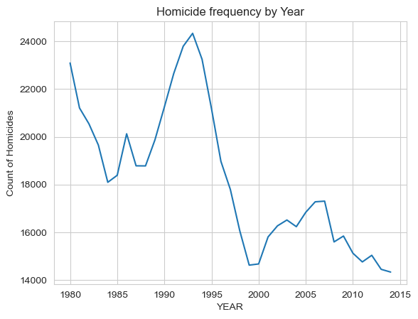

```python
# Group homicides by Year for analysis.
homicide_by_year = homicides_df.reset_index().groupby(by='Year')['Record ID'].count().reset_index()
homicide_by_year.rename(columns={'Record ID': 'Count'}, inplace=True)

# Basic Graph : (update with better graph)
plt.plot(homicide_by_year['Year'], homicide_by_year['Count'])
plt.xlabel("YEAR")  # add X-axis label
plt.ylabel("Count of Homicides")  # add Y-axis label
plt.title("Homicide frequency by Year")  # add title
plt.show()
```

Next, let's take a look at the trend of homicides over certain months and make an observation and inference based on our visualization.

#### Homicide Frequency Over Specific Months :

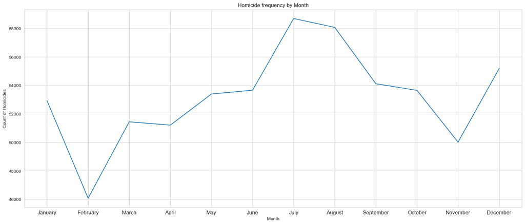

```python
# Group homicides by Month for analysis.
homicide_by_month = homicides_df.reset_index().groupby(by='Month')['Record ID'].count().reset_index()
homicide_by_month.rename(columns={'Record ID': 'Count'}, inplace=True)

# Inculcate sorting mechanism for Month column and sort.
months = ["January", "February", "March", "April", "May", "June",
          "July", "August", "September", "October", "November", "December"]
homicide_by_month['Month'] = pd.Categorical(homicide_by_month['Month'], categories=months, ordered=True)
homicide_by_month.sort_values(by='Month', inplace=True)

# Basic Graph : (update with better graph)
plt.figure(figsize=(20,8))
plt.plot(homicide_by_month['Month'], homicide_by_month['Count'])
plt.xlabel("Month")  # add X-axis label
plt.ylabel("Count of Homicides")  # add Y-axis label
plt.title("Homicide frequency by Month")  # add title
plt.tick_params(axis='x', which='major', labelsize=12)
plt.show()
```

Finally, let's take a look at the trend of homicides over the different seasons and make an observation and inference based on our visualization.

#### Homicide Frequency by Season

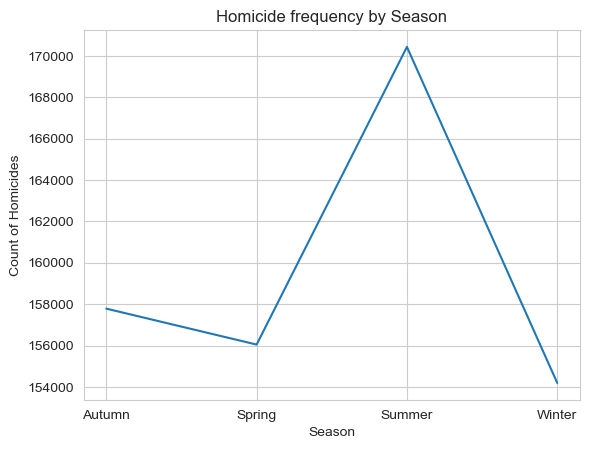

```python
# Define function for creating year-month function for Season wise analysis.
def year_month_conversion(obv):
    return str(obv['Year']) + '-' + str(obv['Month'])

# Create new Year-Month column.
homicides_df['Year-Month'] = homicides_df.apply(lambda obv: str(obv['Year']) + '-' + str(obv['Month']), axis=1)

# Define function to create Season bins.
def season_map(year_month):
    year, month = year_month.split('-')
    if month in ['December', 'January', 'February']:
        return 'Winter'
    elif month in ['March', 'April', 'May']:
        return 'Spring'
    elif month in ['June', 'July', 'August']:
        return 'Summer'
    elif month in ['September', 'October', 'November']:
        return 'Autumn'
    else:
        return 'None'

# Apply the function to create a new 'Season' column
homicides_df['Season'] = homicides_df['Year-Month'].apply(season_map)

# Group homicides by Season for analysis.
homicide_by_season = homicides_df.reset_index().groupby(by='Season')['Record ID'].count().reset_index()
homicide_by_season.rename(columns={'Record ID': 'Count'}, inplace=True)

# Basic Graph : (update with better graph)
plt.plot(homicide_by_season['Season'], homicide_by_season['Count'])
plt.xlabel("Season")  # add X-axis label
plt.ylabel("Count of Homicides")  # add Y-axis label
plt.title("Homicide frequency by Season")  # add title
plt.show()
```

### Let's make an observation based on our visualization :

An observation that we can make here is that the highest number of homicides occur in the summer and the lowest number of homicides occur in the winter.

### Let's make an inference based on our visualization :

Why might this be the case? There might be more homicides that occur in the summer because of the temperature difference. Better weather might spur people to be outside more often and perpetrators have an easier time finding victims. Another reason could be that perpetrators have more free time during the summer, giving them ample time and freedom to commit these crimes.

### **Question of Interest #4 :**

Correlation between perpetrator age vs. victim age. Which generation would be the most affected by homicides? Is there any generation gap between the victim and the perpetrator?

First, let's take a look at the correlation between victim age and perpetrator age and make an observation.

```python
# the corr of the victim age and the perpetrator age
homicides_df['Victim Age'].corr(perpetrator_age)
```

```
0.04191897687588997
```

### Let's make an observation based on the correlation :

The dataset's victim and perpetrator ages show a rather slight positive link, with a correlation coefficient of 0.0419 between them. This indicates that there is a weak correlation between the ages of the offenders and victims increasing together. The positive sign means that the age of the perpetrator tends to increase along with the age of the victim, and vice versa. The tiny correlation coefficient indicates that other factors may be more important in influencing the association between the ages of homicide victims and perpetrators, but it's important to remember that correlation does not imply causation.